# [Academia Hugo](https://gethugothemes.com/products/academia/)

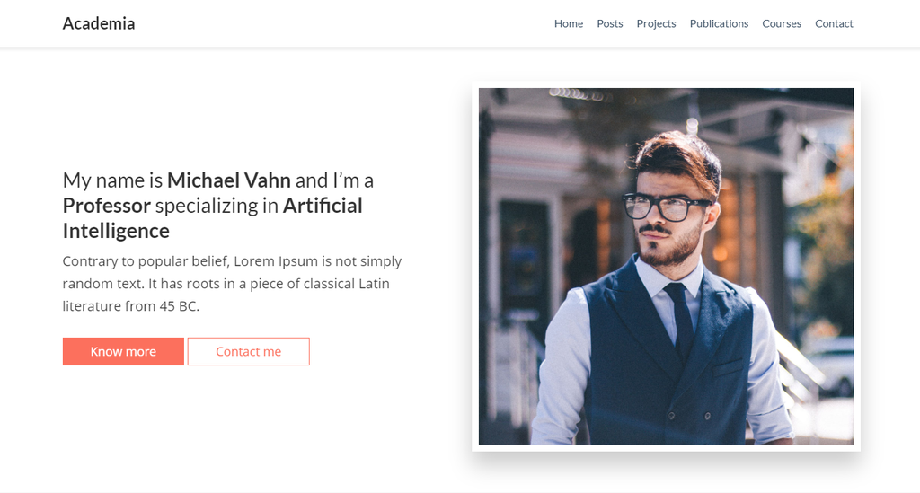

## About

This is an adaptation of the hugo theme starter-academic by wowchemy. It supports most of the features of the original theme, and many new features. We improved the core design and added more latest features .

**Key features:**

- **Page builder** - Create *anything* with [**widgets**](https://sourcethemes.com/academic/docs/page-builder/) and [**elements**](https://sourcethemes.com/academic/docs/writing-markdown-latex/)
- **Edit any type of content** - Blog posts, publications, talks, slides, projects, and more!
- **Create content** in [**Markdown**](https://sourcethemes.com/academic/docs/writing-markdown-latex/), [**Jupyter**](https://sourcethemes.com/academic/docs/jupyter/), or [**RStudio**](https://sourcethemes.com/academic/docs/install/#install-with-rstudio)
- **Plugin System** - Fully customizable [**color** and **font themes**](https://sourcethemes.com/academic/themes/)
- **Display Code and Math** - Code highlighting and [LaTeX math](https://en.wikibooks.org/wiki/LaTeX/Mathematics) supported
- **Integrations** - [Google Analytics](https://analytics.google.com), [Disqus commenting](https://disqus.com), Maps, Contact Forms, and more!
- **Beautiful Site** - Simple and refreshing one page design
- **Industry-Leading SEO** - Help get your website found on search engines and social media
- **Media Galleries** - Display your images and videos with captions in a customizable gallery
- **Mobile Friendly** - Look amazing on every screen with a mobile friendly version of your site
- **Multi-language** - 15+ language packs including English, 中文, and Português
- **Multi-user** - Each author gets their own profile page
- **Privacy Pack** - Assists with GDPR
- **Stand Out** - Bring your site to life with animation, parallax backgrounds, and scroll effects
- **One-Click Deployment** - No servers. No databases. Only files.

## Installation

Navigate to your themes folder in your Hugo site and use the following commands:

**Note : You must use `hugo-extended` version to compile SCSS**

```
$ mkdir themes
$ cd themes
$ git clone git@github.com:themefisher/academia-hugo.git
```

## Main features

- Fully Responsive Ready.
- Powered by bootstrap 4 framework.
- Product Showcase
- Documented codes.

## Reporting Issues

We use GitHub Issues as the official bug tracker for the Academia Template. Please Search [existing issues](https://github.com/themefisher/academia-hugo/issues). It’s possible someone has already reported the same problem. If your problem or idea is not addressed yet, [open a new issue](https://github.com/themefisher/academia-hugo/issues)

## Technical Support or Questions (Paid)

If you have questions or need help integrating the product please contact us instead of opening an issue.

## Hire Us

We are available for Hiring of your next HUGO project. Drop Us a mail mehedi@themefisher.com

## Premium Themes

[figure not shown]

[figure not shown]

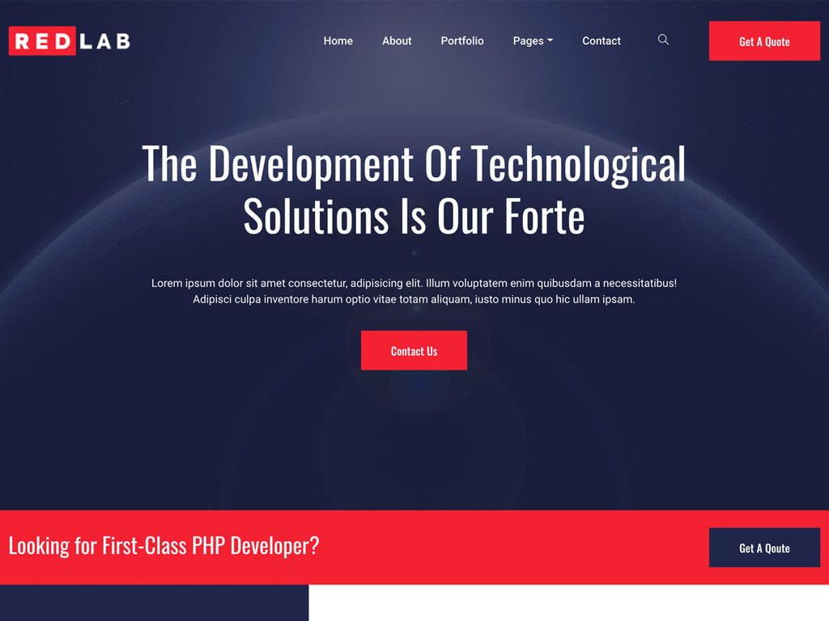

**Hugo Mega Bundle**

**Phantom**

**Red Lab**